# Example import of a Distance analysis

David L Miller

2018-06-05

This is a brief example of how to use the `readdst` package to import all analyses and data from an existing [Distance for Windows](http://distancesampling.org/Distance) project.

## Preliminaries

I assume here that you have a Distance for Windows project file (in this case we’re going to try out the “Golf Tees” example, which is shipped with Distance for Windows). This consists of a file called `Golftees.dst` and a folder named `Golftees.dat`. The folder can contain numerous other files (including R analyses, shapefiles, plots etc) but we’ll ignore everything apart from the `DistData.mdb` file that contains the data used to fit our models.

To read the Access database files (the `.dst` file and `DistData.mdb` you need to have the `Hmisc` package installed and a copy of [`mdb-tools`](http://mdbtools.sourceforge.net/) installed on your computer. On Mac, if you have [`homebrew`](http://brew.sh/) installed, this consists of simply running `brew install mdb-tools`.

*On my Win7 machine, I have neither mdb-tools installed nor do I load the Hmisc package to use readdst. However RODBC is required (and loaded by readdst), user must be using 32-bit version of R*

# General principle

`readdst` looks in the project `.dst` file, extracts the analyses, generates the correct calls to `ddf` and then runs those analyses, using the data it extracted from `DistData.mdb`. The various tables in the Distance for Windows databases relate in the following ways (source: Distance Developer’s manual):

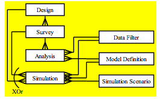

relationship between various tables in Distance

Although all of this is going on in the background, there are only a few functions one actually has to worry about.

# Golf tees

We begin by finding the golf tees project on our computer, because this project is shipped with `readdst` we can use `system.file` to find the path to it:

```r
library(readdst)
project <- system.file("Golftees-example", package="readdst")
project <- paste0(project,"/Golftees")
```

## Converting analyses

We can then convert the whole project and all analyses in it, this just translates the code that Distance uses to fit the model into R code:

```r
converted <- convert_project(project)
```

We can see the names of the analyses (as they were given in Distance for Windows) and their analysis IDs by printing the returned object:

```r
converted
```

```
##    ID                      Name  Status
## 1   3 FI - MR dist+size+sex+exp Not Run
## 2   2              FI - MR dist Not Run
## 3   7                     io.pi Not Run
## 4   9           FI - Petersen 1 Not Run
## 5  10           FI - Petersen 2 Not Run
## 6   1             FI - Petersen  Ran OK
## 7   6                     io.fi  Ran OK
## 8   4      ds (single platform)  Ran OK
## 9   5                     trial  Ran OK
## 10  8            test intervals  Ran OK
```

More detail (including the `mrds` call details) can be found by looking an individual element of the list:

```r
converted[[1]]
```

```
## Model name  : FI - Petersen
## ID          : 1
## Data filter :
## mrds call   : mrds::ddf(mrmodel=~glm(~1, link="logit"), meta.data=list(width=4,left=0), control=list(), method="trial.fi", data=data)
```

## Running analyses

```r
analysis_1 <- run_analysis(converted[[1]], debug=TRUE)
```

```
## Model name: FI - Petersen
## Call:
##  mrds::ddf(mrmodel=~glm(~1, link="logit"), meta.data=list(width=4,left=0), control=list(), method="trial.fi", data=data)
```

```r
summary(analysis_1)
```

```
##
## Summary for trial.fi object
## Number of observations               :  162
## Number seen by primary               :  124
## Number seen by secondary (trials)    :  142
## Number seen by both (detected trials):  104
## AIC                                  :  510.766
##
##
## Conditional detection function parameters:
##             estimate       se
## (Intercept) 1.006805 0.189555
##
##                         Estimate          SE         CV
## Average p              0.7323944  0.03799900 0.05188325
## Average primary p(0)   0.7323944  0.03715144 0.05072601
## N in covered region  169.3076923 11.64565922 0.06878399
```

Since this is just a fitted object from `mrds` we can do normal stuff like make plots:

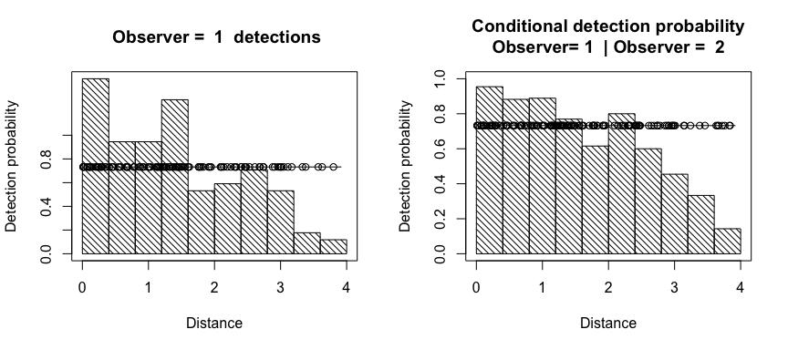

Plot results from `analysis_1`.

```r
par(mfrow=c(1,2))
plot(analysis_1)
```

If one wanted to run all the analysis at once, one could of course simply use `lapply`.

## Testing that Distance and R got the same answer

We can test the saved results in Distance against those from R using `test_stats`. This produces a table comparing the values stored in the Distance for Windows project database and their corresponding values calculated using R:

```r
test_stats(converted[[1]])
```

```
##         Statistic     Distance_value         mrds_value         Difference
## 1             AIC         510.765991    510.76603075588    0.0000000778358
## 2  log-likelihood           -254.383           -254.383                  0
## 3         density        0.309649706   0.30964972527496   0.00000004932979
## 4     CV(density)         0.07345434         0.08365404          0.1388577
## 5     individuals 520.21148700000003 520.21153846192703   0.00000009892501
## 6 CV(individuals)         0.07345434         0.08365404          0.1388577
##   Pass
## 1    ✓
## 2    ✓
## 3    ✓
## 4
## 5    ✓
## 6
```